# Using Simulation to Explore the Central Limit Theorem

Connor Claypool

18 June 2018

# Introduction

The Central Limit Theorem (CLT) states that the means of samples of *n* independent and identically distributed (IID) random variables are approximately normally distributed when *n* is large - regardless of the underlying distribution of the individual random variables which make up the samples. To demonstrate this principle, we will simulate 40,000 IID exponential random variables, grouped into 1000 samples of size 40. First, we will compare the theoretical values for the mean and variance of the sample means with the values observed from our simulations. We will then visually compare the distribution of the individual random variables, which will obviously follow the exponential distribution, with the distribution of the sample means, which should, by the CLT, approximate a normal distribution.

# Simulation

The first step is to simulate the 40,000 random variables and organise these into samples. We will use R to generate a matrix with 1000 rows and 40 columns, polulated with exponential random variables with a rate of 0.2. We wil also calculate the sample means. Note that we set the random seed to ensure reproducibility.

```r
set.seed(3791)

simulated_data <- matrix(rexp(40000, rate = 0.2), nrow = 1000, ncol = 40)
sample_means <- apply(simulated_data, 1, mean)
```

# Observed Mean vs Theoretical Mean

As sample means are an unbiased estimator of the population mean, the mean sample mean should equal to the population mean. We can test whether this is the case over our 1000 simulated samples by comparing the mean of these sample means with the known population mean (1 divided by the rate parameter set when generating the random variables).

```r
theoretical_mean <- 1/0.2
observed_mean <- mean(sample_means)

print(paste("Theoretical mean of sample means:", theoretical_mean))
```

```
## [1] "Theoretical mean of sample means: 5"
```

```r
print(paste("Observed mean of sample means", observed_mean))
```

```
## [1] "Observed mean of sample means 5.00881012991511"
```

So the difference between the observed and theoretical means is only 0.0088101. A small difference can be expected due to Monte Carlo error resulting from the finite size of our simulation.

# Observed Variance vs Theoretical Variance

The variance of the mean of samples of *n* IID random variables each with variance $\sigma^2$ is $\sigma^2/n$. We can use this rule to calculate the theoretical variance of the sample means, and compare this to the observed variance.

```r
theoretical_variance <- ((1/0.2)^2)/40
observed_variance <- var(sample_means)

print(paste("Theoretical variance of sample means:", theoretical_variance))
```

```
## [1] "Theoretical variance of sample means: 0.625"
```

```r
print(paste("Observed variance of sample means:", observed_variance))
```

```
## [1] "Observed variance of sample means: 0.649620250601754"
```

So the difference between the theoretical and observed values this time is 0.0246203.

# Underlying Distribution vs Sample Mean Distribution

We have found the observed and theoretical values for the mean and variance of the sample means to be very similar, but this is no guarantee of the shape of the distribution. First, in order to appreciate the difference, we will visually compare the distribution of the 40,000 IID exponential random variables, i.e. the exponential distribution, with the normal distribution having the same mean and variance.

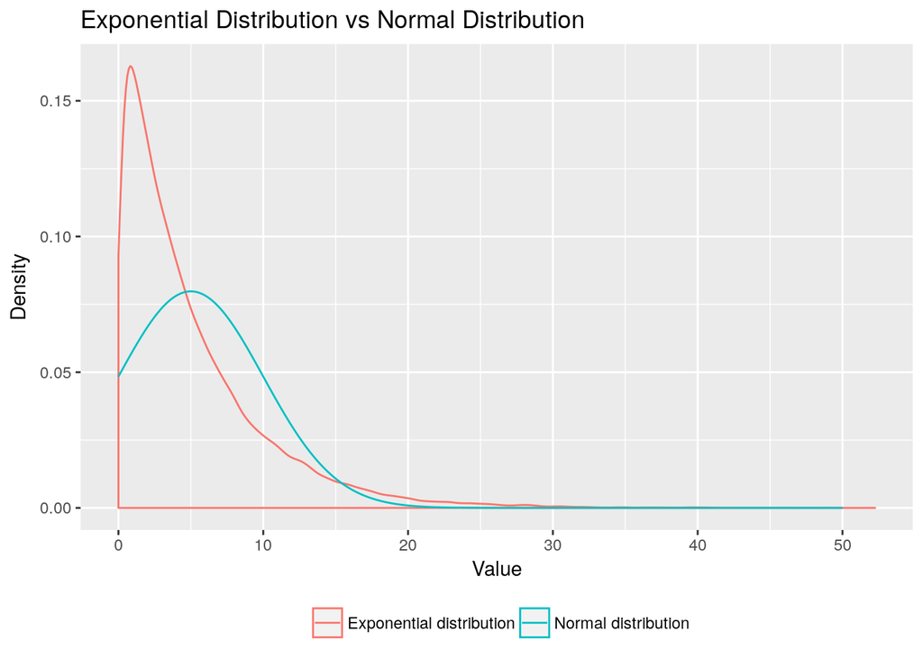

```r
normal_densities <- dnorm(seq(0, 50, 0.05), mean = 1/0.2, sd = 1/0.2)

library(ggplot2)
ggplot() +
    geom_density(data = data.frame(rv = as.vector(simulated_data)),
                 aes(x = rv, color = "Exponential distribution")) +
    geom_line(data = data.frame(q = seq(0, 50, 0.05), d = normal_densities),
              aes(x = q, y = d, color = "Normal distribution")) +
    theme(legend.position = "bottom", legend.title = element_blank()) +
    xlab("Value") +
    ylab("Density") +
    ggtitle("Exponential Distribution vs Normal Distribution")
```

Clearly, these distributions differ significantly. Now, we will compare the distribution of the means of samples of 40 exponential random variables with the normal distribution which has the theoretical mean and variance discussed previously.

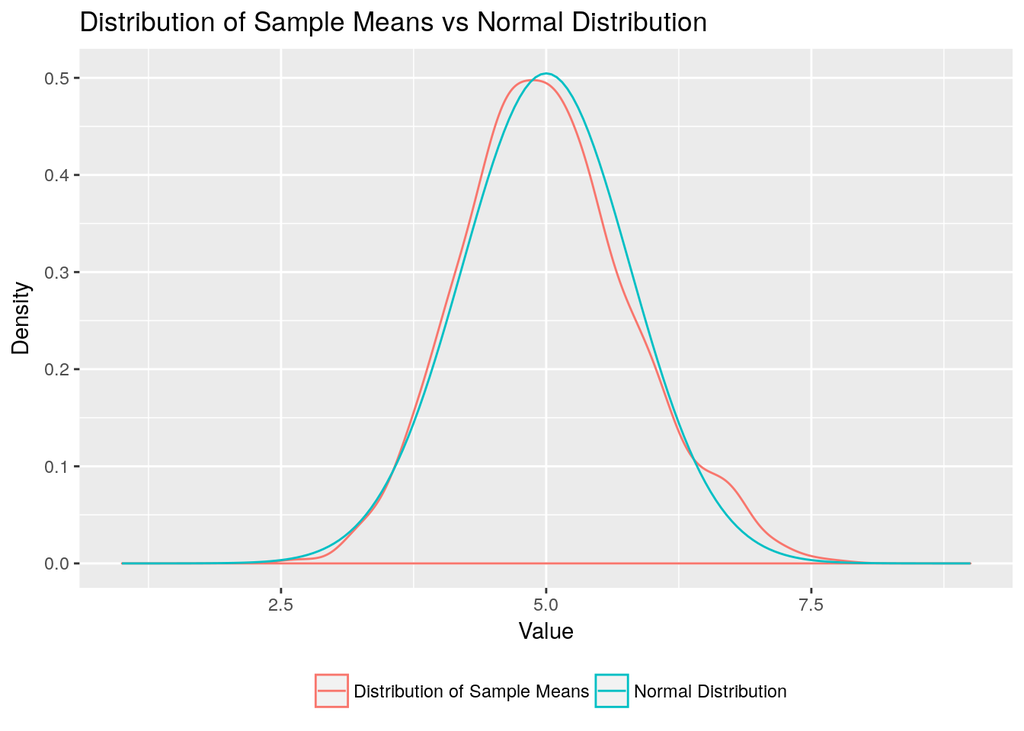

```r
normal_densities_sm <- dnorm(seq(1, 9, 0.05),
                          mean = theoretical_mean,
                          sd = sqrt(theoretical_variance))

ggplot() +
    geom_density(data = data.frame(sm = sample_means),
                 aes(x = sm, color = "Distribution of Sample Means")) +
    geom_line(data = data.frame(q = seq(1, 9, 0.05), d = normal_densities_sm),
              aes(x = q, y = d, color = "Normal Distribution")) +
    theme(legend.position = "bottom", legend.title = element_blank()) +
    xlab("Value") +
    ylab("Density") +
    ggtitle("Distribution of Sample Means vs Normal Distribution")
```

This plot shows that the normal distribution is an excellent approximation of the distribution of sample means, which is very close to, though not exactly like, the normal ‘bell curve’. Moreover, this is the case despite the underlying distribution of the indiviudual variables making up the samples being distributed in a very different way.